# Regression-Models-Project

Abhijeet

### Synopsis

The following analysis is done on the “mtcars” data in the R dataset package and explore the relationship between a set of variables and miles per gallon (MPG) (outcome).

1. “Is an automatic or manual transmission better for MPG”
2. “Quantify the MPG difference between automatic and manual transmissions”

### Data Processing

- Description The data was extracted from the 1974 Motor Trend US magazine, and comprises fuel consumption and 10 aspects of automobile design and performance for 32 automobiles (1973–74 models).

```r
#libraries
library(datasets);library(ggplot2);require(stats); require(graphics)

data(mtcars)
```

### Exploratory Analysis

```r
?mtcars
```

```
## starting httpd help server ... done
```

```r
summary(mtcars)
```

```
##       mpg             cyl             disp             hp
##  Min.   :10.40   Min.   :4.000   Min.   : 71.1   Min.   : 52.0
##  1st Qu.:15.43   1st Qu.:4.000   1st Qu.:120.8   1st Qu.: 96.5
##  Median :19.20   Median :6.000   Median :196.3   Median :123.0
##  Mean   :20.09   Mean   :6.188   Mean   :230.7   Mean   :146.7
##  3rd Qu.:22.80   3rd Qu.:8.000   3rd Qu.:326.0   3rd Qu.:180.0
##  Max.   :33.90   Max.   :8.000   Max.   :472.0   Max.   :335.0
##       drat             wt             qsec             vs
##  Min.   :2.760   Min.   :1.513   Min.   :14.50   Min.   :0.0000
##  1st Qu.:3.080   1st Qu.:2.581   1st Qu.:16.89   1st Qu.:0.0000
##  Median :3.695   Median :3.325   Median :17.71   Median :0.0000
##  Mean   :3.597   Mean   :3.217   Mean   :17.85   Mean   :0.4375
##  3rd Qu.:3.920   3rd Qu.:3.610   3rd Qu.:18.90   3rd Qu.:1.0000
##  Max.   :4.930   Max.   :5.424   Max.   :22.90   Max.   :1.0000
##        am              gear            carb
##  Min.   :0.0000   Min.   :3.000   Min.   :1.000
##  1st Qu.:0.0000   1st Qu.:3.000   1st Qu.:2.000
##  Median :0.0000   Median :4.000   Median :2.000
##  Mean   :0.4062   Mean   :3.688   Mean   :2.812
##  3rd Qu.:1.0000   3rd Qu.:4.000   3rd Qu.:4.000
##  Max.   :1.0000   Max.   :5.000   Max.   :8.000
```

The data frame contains 32 observations on 11 (numeric) variables.

1. mpg Miles/(US) gallon
2. cyl Number of cylinders
3. disp Displacement (cu.in.)
4. hp Gross horsepower
5. drat Rear axle ratio
6. wt Weight (1000 lbs)
7. qsec 1/4 mile time
8. vs Engine (0 = V-shaped, 1 = straight)
9. am Transmission (0 = automatic, 1 = manual)
10. gear Number of forward gears
11. carb Number of carburetors

[figure not shown]

```r
boxplot(mtcars$mpg~mtcars$am,main="mtcars data",xlab="mpg(Miles/(US) gallon)",ylab="am(Transmission)")
```

Checking Normality

```r
shapiro.test(mtcars$mpg)
```

```
##
##  Shapiro-Wilk normality test
##
## data:  mtcars$mpg
## W = 0.94756, p-value = 0.1229
```

- The P-value of the Shapiro-Wilk normality test must be greater than 0.05 for assuming normality. Hence, the mpg(Miles/(US) gallon ) data is normally distributed.

```r
t.test(mtcars$mpg~mtcars$am, paired = FALSE, var.equal = FALSE)
```

```
##
##  Welch Two Sample t-test
##
## data:  mtcars$mpg by mtcars$am
## t = -3.7671, df = 18.332, p-value = 0.001374
## alternative hypothesis: true difference in means between group 0 and group 1 is not equal to 0
## 95 percent confidence interval:
##  -11.280194  -3.209684
## sample estimates:
## mean in group 0 mean in group 1
##        17.14737        24.39231
```

- From the above test it is ensured that null Hypothesis(p-value < Significance level) can be rejected at 5% significance level. The mpg(miles per gallon) is higher for manual transmission and there is a significant difference between the auto and manual transmission

### Regression model

#### logistic regression

First, lets check the dependency of miles per gallon(mpg) and transmission(am), particularly looking to answer the following question:

“Is an automatic or manual transmission better for MPG?”

In this test the outcome is binary or categorical variable 0 and 1.Thus use logistic regression.

```r
fit<-glm(am~mpg,data=mtcars, family ="binomial")
summary(fit)
```

```
##
## Call:
## glm(formula = am ~ mpg, family = "binomial", data = mtcars)
##
## Coefficients:
##             Estimate Std. Error z value Pr(>|z|)
## (Intercept)  -6.6035     2.3514  -2.808  0.00498 **
## mpg           0.3070     0.1148   2.673  0.00751 **
## ---
## Signif. codes:  0 '***' 0.001 '**' 0.01 '*' 0.05 '.' 0.1 ' ' 1
##
## (Dispersion parameter for binomial family taken to be 1)
##
##     Null deviance: 43.230  on 31  degrees of freedom
## Residual deviance: 29.675  on 30  degrees of freedom
## AIC: 33.675
##
## Number of Fisher Scoring iterations: 5
```

```r
exp(fit$coefficients)
```

```
## (Intercept)         mpg
## 0.001355579 1.359379288
```

Plot the predicted outcome

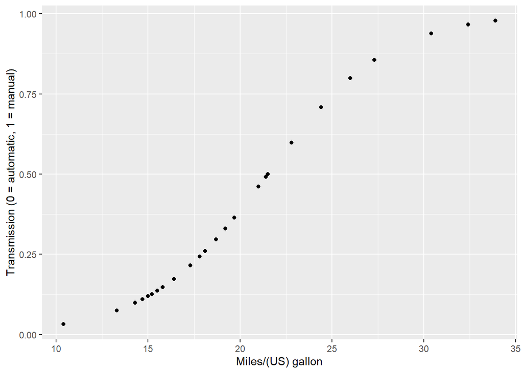

```r
g=ggplot(mtcars,aes(mpg,fit$fitted.values))
g=g+geom_point()+xlab("Miles/(US) gallon")+ylab("Transmission (0 = automatic, 1 = manual)")
g
```

### Multilinnear regression model testing

```r
fit1<-lm(mpg ~ factor(am) + factor(cyl), data=mtcars)
fit2<-lm(mpg ~ factor(am) + factor(cyl)+ hp, data=mtcars)
fit3<-lm(mpg ~ factor(am) + factor(cyl)+ wt +hp, data=mtcars)
fit4<-lm(mpg ~ factor(am) + factor(cyl)+ wt +hp +disp, data=mtcars)
fit5<-lm(mpg~., data=mtcars)

anova(fit1,fit2,fit3,fit4,fit5)
```

```
## Analysis of Variance Table
##
## Model 1: mpg ~ factor(am) + factor(cyl)
## Model 2: mpg ~ factor(am) + factor(cyl) + hp
## Model 3: mpg ~ factor(am) + factor(cyl) + wt + hp
## Model 4: mpg ~ factor(am) + factor(cyl) + wt + hp + disp
## Model 5: mpg ~ cyl + disp + hp + drat + wt + qsec + vs + am + gear + carb
##   Res.Df    RSS Df Sum of Sq      F   Pr(>F)
## 1     28 264.50
## 2     27 197.20  1    67.297 9.5816 0.005481 **
## 3     26 151.03  1    46.173 6.5741 0.018084 *
## 4     25 150.41  1     0.617 0.0878 0.769882
## 5     21 147.49  4     2.914 0.1037 0.979949
## ---
## Signif. codes:  0 '***' 0.001 '**' 0.01 '*' 0.05 '.' 0.1 ' ' 1
```

```r
fit2<-lm(mpg ~ factor(am) + factor(cyl)+ hp, data=mtcars)
anova(fit2)
```

```
## Analysis of Variance Table
##
## Response: mpg
##             Df Sum Sq Mean Sq F value    Pr(>F)
## factor(am)   1 405.15  405.15 55.4722 5.183e-08 ***
## factor(cyl)  2 456.40  228.20 31.2446 9.430e-08 ***
## hp           1  67.30   67.30  9.2141  0.005266 **
## Residuals   27 197.20    7.30
## ---
## Signif. codes:  0 '***' 0.001 '**' 0.01 '*' 0.05 '.' 0.1 ' ' 1
```

```r
summary(fit2)
```

```
##
## Call:
## lm(formula = mpg ~ factor(am) + factor(cyl) + hp, data = mtcars)
##
## Residuals:
##    Min     1Q Median     3Q    Max
## -5.231 -1.535 -0.141  1.408  5.322
##
## Coefficients:
##              Estimate Std. Error t value Pr(>|t|)
## (Intercept)  27.29590    1.42394  19.169  < 2e-16 ***
## factor(am)1   4.15786    1.25655   3.309  0.00266 **
## factor(cyl)6 -3.92458    1.53751  -2.553  0.01666 *
## factor(cyl)8 -3.53341    2.50279  -1.412  0.16943
## hp           -0.04424    0.01458  -3.035  0.00527 **
## ---
## Signif. codes:  0 '***' 0.001 '**' 0.01 '*' 0.05 '.' 0.1 ' ' 1
##
## Residual standard error: 2.703 on 27 degrees of freedom
## Multiple R-squared:  0.8249, Adjusted R-squared:  0.7989
## F-statistic: 31.79 on 4 and 27 DF,  p-value: 7.401e-10
```

## Apendix

### Appendix A -Data Processing

```r
library(GGally)
```

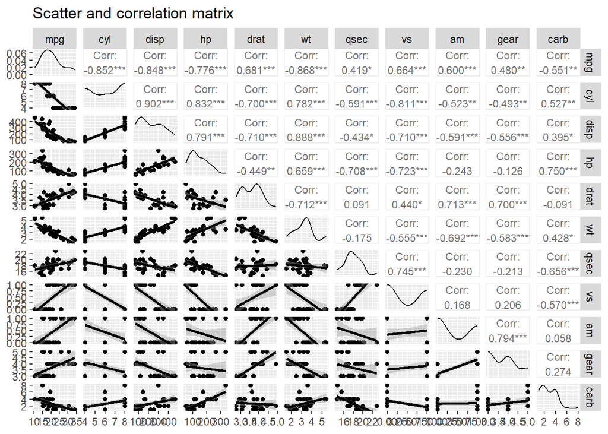

```r
options(repr.plot.width = 30, repr.plot.height = 30)
ggpairs(mtcars,  title = "Scatter and correlation matrix",upper = list(continuous = wrap("cor",size = 3)),
    lower = list(continuous = wrap("smooth")))
```

Normality visulization

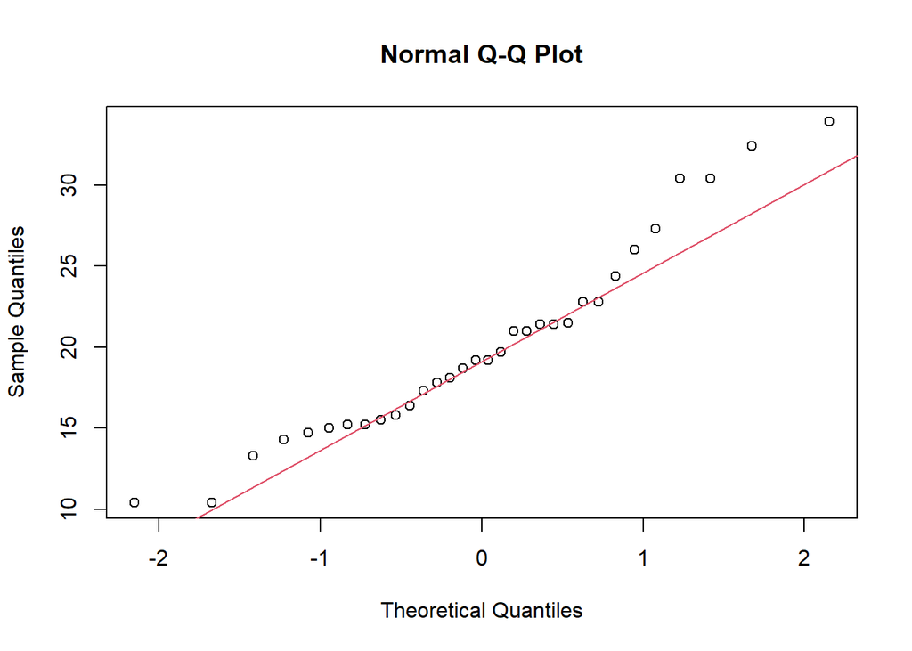

```r
qqnorm(mtcars$mpg)
qqline(mtcars$mpg,col=2)
```